# 沙市堂 主日崇拜

2026年9月20日（主日）上午9:00  
主礼：张强 传道；证道：彭金文 牧师。

晚堂：19:00，香榭丽都聚会点（江津中路）；主礼：丁志云 传道；证道：彭金文 牧师。

## 今日主题

今天一起学习饶恕，也学习怎样与人相处。神先爱我们、赦免我们，我们便学习用爱心待人：有隔阂时愿意和好，有分歧时耐心相待。读经、唱诗和祷告，都帮助我们把这份爱带进每天的生活。

记住这一句：

> 主怎样饶恕了你们，你们也要怎样饶恕人。

歌罗西书3:13（节选）

## 逐项解读

### 1．序乐

众立·安静

奏乐时，诗班和带领聚会的人入堂。大家站立，安静预备心。

诗本：赞美诗（新编）；投影常用简谱。

返回程序一览 ↑

### 2．问安 · 赞美诗396《主在圣殿中》

众立·同唱

哈巴谷书2:20

<sup>20</sup>惟耶和华在他的圣殿中；全地的人都当在他面前肃敬静默。

主在圣殿中，主在圣殿中，普天下的人，在主面前都应当肃静，肃静，肃静，应当肃静。阿们。

这首短歌请大家在主面前安静下来。站着轻声同唱，主礼问候“弟兄姊妹，主内平安”时，大家可以回应“平安”。

曲：鲁特

查看歌谱 ↓

返回程序一览 ↑

### 3．宣召 · 诗篇103:8–12

众立

诗篇103:8–12

<sup>8</sup>耶和华有怜悯，有恩典，不轻易发怒，且有丰盛的慈爱。

<sup>9</sup>他不长久责备，也不永远怀怒。

<sup>10</sup>他没有按我们的罪过待我们，也没有照我们的罪孽报应我们。

<sup>11</sup>天离地何等的高，他的慈爱向敬畏他的人也是何等的大！

<sup>12</sup>东离西有多远，他叫我们的过犯离我们也有多远！

这是大卫的诗，第8节也让我们想起神向摩西说过的话。诗中用天的高、东西的远，描画神的爱与赦免。大家站着听，把自己的重担交给他。

返回程序一览 ↑

### 4．唱诗 · 赞美诗23《赞美歌》

众立·同唱

**1．**赞美上帝，为我们完成了救赎，我众来到主面前，献上礼物；虔诚供奉主前，屈膝敬拜不止，来感谢主圣名，欢唱赞美主。

**2．**先贤之神，恳求你听我们倾诉，蒙主引导经试炼，风波安渡；每当患难临头，主必引领出险，生活能够得胜，全靠主帮助。

**3．**敬献颂赞，有救主为我们引路，真诚感谢颂扬主，我众欢呼；因主在我身旁，有主膀臂护卫，我们感谢歌唱，永远赞美主。阿们。

三段歌词带我们感谢主的拯救，回想患难中的帮助，再赞美他的看顾。大家站着同唱，也想一想自己受过的帮助。

词：科里；中文：杨旅复

查看歌谱 ↓

返回程序一览 ↑

### 5．祷告

众立·安静

主礼带领大家祷告，通常会赞美神、认罪，并求神与聚会同在。大家站着安静跟随，结束时同声说“阿们”。

返回程序一览 ↑

### 6．宣信 · 赞美诗395《使徒信经》

众立·同诵

我信上帝，全能的父，创造天地的主。我信我主耶稣基督，上帝独生的子；因圣灵感孕，由童贞女马利亚所生；在本丢彼拉多手下受难，被钉于十字架，受死，埋葬；降在阴间，第三天从死人中复活；升天，坐在全能父上帝的右边；将来必从那里降临，审判活人死人。我信圣灵；我信圣而公之教会；我信圣徒相通；我信罪得赦免；我信身体复活；我信永生。阿们。

大家站着，一同说出共同相信的内容。可以跟着带领慢慢诵读。

查看歌谱 ↓

歌谱第二页 ↓

返回程序一览 ↑

### 7．诗班献唱 · 《爱的真谛》

众坐

哥林多前书13:4–8（第8节前半句）

<sup>4</sup>爱是恒久忍耐，又有恩慈；爱是不嫉妒；爱是不自夸，不张狂，

<sup>5</sup>不做害羞的事，不求自己的益处，不轻易发怒，不计算人的恶，

<sup>6</sup>不喜欢不义，只喜欢真理；

<sup>7</sup>凡事包容，凡事相信，凡事盼望，凡事忍耐。

<sup>8</sup>爱是永不止息。

保罗提醒哥林多的教会，爱要从怎样待人看出来。大家坐着聆听，想一想自己可以怎样关心身边的人。歌曲把“不计算人的恶”唱作“不计算人家的恶”，这里保留圣经原句。

曲：简铭耀

返回程序一览 ↑

### 8．经训 · 创世记50:15–21；罗马书14:1–12；马太福音18:21–35

会众同应·站坐听带领

三段经训采用会众同应，请听带领，按提示一起读。程序单没有注明这一项站立还是坐下，跟随现场安排即可。

#### 创世记 · 约瑟与哥哥们

创世记50:15–21

<sup>15</sup>约瑟的哥哥们见父亲死了，就说：「或者约瑟怀恨我们，照着我们从前待他一切的恶足足地报复我们。」

<sup>16</sup>他们就打发人去见约瑟，说：「你父亲未死以先吩咐说：『

<sup>17</sup>你们要对约瑟这样说：从前你哥哥们恶待你，求你饶恕他们的过犯和罪恶。』如今求你饶恕你父亲神之仆人的过犯。」他们对约瑟说这话，约瑟就哭了。

<sup>18</sup>他的哥哥们又来俯伏在他面前，说：「我们是你的仆人。」

<sup>19</sup>约瑟对他们说：「不要害怕，我岂能代替神呢？

<sup>20</sup>从前你们的意思是要害我，但神的意思原是好的，要保全许多人的性命，成就今日的光景。

<sup>21</sup>现在你们不要害怕，我必养活你们和你们的妇人孩子。」于是约瑟用亲爱的话安慰他们。

哥哥们从前把约瑟卖到外地，父亲雅各死后，他们担心约瑟报复。约瑟却安慰他们，还答应养活他们一家，让原谅成为实际的照顾。

#### 罗马书 · 接纳彼此

罗马书14:1–12

<sup>1</sup>信心软弱的，你们要接纳，但不要辩论所疑惑的事。

<sup>2</sup>有人信百物都可吃；但那软弱的，只吃蔬菜。

<sup>3</sup>吃的人不可轻看不吃的人；不吃的人不可论断吃的人；因为神已经收纳他了。

<sup>4</sup>你是谁，竟论断别人的仆人呢？他或站住或跌倒，自有他的主人在；而且他也必要站住，因为主能使他站住。

<sup>5</sup>有人看这日比那日强；有人看日日都是一样。只是各人心里要意见坚定。

<sup>6</sup>守日的人是为主守的。吃的人是为主吃的，因他感谢神；不吃的人是为主不吃的，也感谢神。

<sup>7</sup>我们没有一个人为自己活，也没有一个人为自己死。

<sup>8</sup>我们若活着，是为主而活；若死了，是为主而死。所以，我们或活或死总是主的人。

<sup>9</sup>因此，基督死了，又活了，为要作死人并活人的主。

<sup>10</sup>你这个人，为甚么论断弟兄呢？又为甚么轻看弟兄呢？因我们都要站在神的台前。

<sup>11</sup>经上写着：主说：我凭着我的永生起誓：万膝必向我跪拜；万口必向我承认。

<sup>12</sup>这样看来，我们各人必要将自己的事在神面前说明。

罗马的教会有人吃各种食物，有人只吃蔬菜，也有人看重特别的日子。保罗劝他们彼此接纳，因为每个人都属于主，要向主交代自己的生活。

#### 马太福音 · 从心里原谅

马太福音18:21–35

<sup>21</sup>那时，彼得进前来，对耶稣说：「主啊，我弟兄得罪我，我当饶恕他几次呢？到七次可以吗？」

<sup>22</sup>耶稣说：「我对你说，不是到七次，乃是到七十个七次。

<sup>23</sup>天国好像一个王要和他仆人算帐。

<sup>24</sup>才算的时候，有人带了一个欠一千万银子的来。

<sup>25</sup>因为他没有甚么偿还之物，主人吩咐把他和他妻子儿女，并一切所有的都卖了偿还。

<sup>26</sup>那仆人就俯伏拜他，说：『主啊，宽容我，将来我都要还清。』

<sup>27</sup>那仆人的主人就动了慈心，把他释放了，并且免了他的债。

<sup>28</sup>「那仆人出来，遇见他的一个同伴欠他十两银子，便揪着他，掐住他的喉咙，说：『你把所欠的还我！』

<sup>29</sup>他的同伴就俯伏央求他，说：『宽容我吧，将来我必还清。』

<sup>30</sup>他不肯，竟去把他下在监里，等他还了所欠的债。

<sup>31</sup>众同伴看见他所做的事就甚忧愁，去把这事都告诉了主人。

<sup>32</sup>于是主人叫了他来，对他说：『你这恶奴才！你央求我，我就把你所欠的都免了，

<sup>33</sup>你不应当怜恤你的同伴，像我怜恤你吗？』

<sup>34</sup>主人就大怒，把他交给掌刑的，等他还清了所欠的债。

<sup>35</sup>你们各人若不从心里饶恕你的弟兄，我天父也要这样待你们了。」

彼得问原谅人要到几次，耶稣用故事回答他。一个人被免去大债，却不肯宽待欠他小债的人，主人便责问他。领受了宽容，也要把宽容给别人。

返回程序一览 ↑

### 9．读经 · 歌罗西书3:12–17

众坐

歌罗西书3:12–17

<sup>12</sup>所以，你们既是神的选民，圣洁蒙爱的人，就要存怜悯、恩慈、谦虚、温柔、忍耐的心。

<sup>13</sup>倘若这人与那人有嫌隙，总要彼此包容，彼此饶恕；主怎样饶恕了你们，你们也要怎样饶恕人。

<sup>14</sup>在这一切之外，要存着爱心，爱心就是联络全德的。

<sup>15</sup>又要叫基督的平安在你们心里作主；你们也为此蒙召，归为一体；且要存感谢的心。

<sup>16</sup>当用各样的智慧，把基督的道理丰丰富富地存在心里，用诗章、颂词、灵歌，彼此教导，互相劝戒，心被恩感，歌颂神。

<sup>17</sup>无论做甚么，或说话或行事，都要奉主耶稣的名，藉着他感谢父神。

保罗写信劝勉歌罗西的信徒，把所信的活在日常生活里。这段话先说我们属于谁，再说怎样待人、怎样一起生活。大家坐着听，这也是下面讲道所用的经文。

本页经文用和合本；上方小数字是节数。

返回程序一览 ↑

### 10．唱诗 · 赞美诗250《我属耶稣歌》

众立·同唱

**1．**我乃属耶稣，我听闻主声，主恩爱充满我心；今求赐信心，靠赖主膀臂，常与主相近相亲。

**2．**今归主为圣，专为主所用，每日蒙新赐天恩；信望爱日增，口不住称颂，按主旨意度一生。

**3．**恩座前祈祷，与我主亲近，似良友亲密相交；心喜乐难言，真得福无尽，主恩甜美无限好。

**4．**何其深主爱！我无法测度，直到与主面对面；何等大喜乐！我难以述说，直到安息主怀间。

**副歌：**更亲近主，亲近我恩主，来到主受死圣架！更亲近主，近主，亲近我恩主，到主流血宝架下！阿们。

这首歌表达亲近耶稣、愿意照他的心意生活的心愿。大家站着同唱，每段之后跟随带领唱副歌。

词：克罗斯比；曲：多恩

查看歌谱 ↓

返回程序一览 ↑

### 11．证道 · 《上帝选民该有的生活样式》

众坐·安静

彭金文牧师讲解歌罗西书3:12–17，大家坐着安静听。以下按程序单大纲和经文帮助预备，具体内容请听当天的讲解。

#### 一、要认识我们的身份是神的选民（12节前半节）

先记得自己是神所爱的人，再学习怎样生活。

#### 二、要知道神的选民该有什么品格（12节后半节—14节）

把怜悯、恩慈、谦虚、温柔、忍耐用在相处中，有了嫌隙仍愿意包容、饶恕。爱心把这些美德连在一起。

#### 三、要遵行团契生活中相处的原则（15–17节）

意见不同时，让基督的平安作主；借着教导和唱诗，把主的话存在心里。说话做事都照主的心意，常存感谢。

返回程序一览 ↑

### 12．堂务报告

众坐

坐着听教会这一周的聚会和安排，留意时间、地点与需要帮助的人。实际安排以现场报告为准。

返回程序一览 ↑

### 13．欢迎第一次来的朋友

众坐

大家坐着欢迎新朋友，可以微笑、鼓掌。第一次来的人若受邀站起或举手，照着提示回应即可。

返回程序一览 ↑

### 14．祷告 · 为有需要者祷告

众坐·安静

大家为病人、失去亲人的家庭，以及教会和国家祈求。坐着安静跟随，把自己挂念的人也放在心里，结束时说“阿们”。

返回程序一览 ↑

### 15．唱诗 · 赞美诗357《爱人歌》

众立·同唱

**1．**弟兄们啊，放开胸怀爱众人，哀怜所在，即主平安所临；彼此相爱，崇拜才能尽虔诚，祈祷颂扬，莫离和颜善行。

**4．**到那时期，人身桎梏都落下，世界众生，不闻战乐悲笳；忿怒的火，将被爱心所践踏，死灰之中，盛放和平之花。阿们。

这首歌提醒我们，敬拜也要成为和气待人、照顾孤苦的行动。大家站着同唱，盼望爱心除去怒气，带来和平。

词：惠蒂尔；曲：巴恩比；中文：刘廷芳、杨荫浏

查看歌谱 ↓

返回程序一览 ↑

### 16．主祷文 · 马太福音6:9–13

众立·同诵

马太福音6:9–13

<sup>9</sup>所以，你们祷告要这样说：我们在天上的父：愿人都尊你的名为圣。

<sup>10</sup>愿你的国降临；愿你的旨意行在地上，如同行在天上。

<sup>11</sup>我们日用的饮食，今日赐给我们。

<sup>12</sup>免我们的债，如同我们免了人的债。

<sup>13</sup>不叫我们遇见试探；救我们脱离凶恶。因为国度、权柄、荣耀，全是你的，直到永远。阿们！

#### 一同诵读

我们在天上的父，愿人都尊你的名为圣。愿你的国降临，愿你的旨意行在地上，如同行在天上。我们日用的饮食，今日赐给我们。免我们的债，如同我们免了人的债。不叫我们遇见试探，救我们脱离凶恶。因为国度、权柄、荣耀，全是你的，直到永远。阿们。

主耶稣教大家这样祷告，把每天的需要、过错和担忧交给天父。大家站着同诵，也愿意像自己求得赦免一样原谅别人。

返回程序一览 ↑

### 17．祝福

众立

#### 民数记6:24–26 · 亚伦的祝福

<sup>24</sup>愿耶和华赐福给你，保护你。

<sup>25</sup>愿耶和华使他的脸光照你，赐恩给你。

<sup>26</sup>愿耶和华向你仰脸，赐你平安。

#### 哥林多后书13:14

<sup>14</sup>愿主耶稣基督的恩惠、神的慈爱、圣灵的感动，常与你们众人同在！

牧师通常用这两段经文中的一段为大家祝福，今天用哪段请听现场带领。大家站立，用心领受这份看顾与平安。

返回程序一览 ↑

### 18．阿们颂

众立·同唱

阿们，阿们，阿们。

大家站着同唱，回应刚才的祷告和祝福，唱几次请跟随带领。结束后，诗班和带领聚会的人退堂，大家可以彼此问候“主内平安”。

返回程序一览 ↑

## 今日金句

1. 耶和华有怜悯，有恩典，不轻易发怒，且有丰盛的慈爱。

   诗篇103:8
2. 东离西有多远，他叫我们的过犯离我们也有多远！

   诗篇103:12
3. 从前你们的意思是要害我，但神的意思原是好的，要保全许多人的性命，成就今日的光景。

   创世记50:20
4. 这样看来，我们各人必要将自己的事在神面前说明。

   罗马书14:12
5. 倘若这人与那人有嫌隙，总要彼此包容，彼此饶恕；主怎样饶恕了你们，你们也要怎样饶恕人。

   歌罗西书3:13
6. 在这一切之外，要存着爱心，爱心就是联络全德的。

   歌罗西书3:14
7. 爱是永不止息。

   哥林多前书13:8，前半句
8. 免我们的债，如同我们免了人的债。

   马太福音6:12

## 附录

原程序单后是六页五线谱。在手机上可用两根手指放大；每页下方可返回相应程序。

原程序单

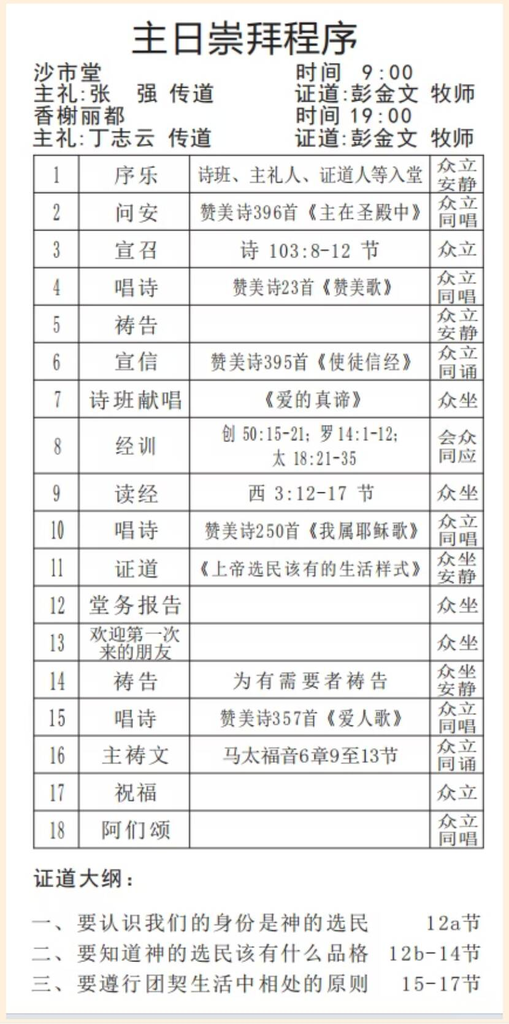

返回程序一览 ↑

赞美诗23《赞美歌》

[figure not shown]

返回第4项 ↑

赞美诗250《我属耶稣歌》

[figure not shown]

返回第10项 ↑

赞美诗357《爱人歌》

[figure not shown]

返回第15项 ↑

赞美诗396《主在圣殿中》

[figure not shown]

返回第2项 ↑

赞美诗395《使徒信经》（第一页）

[figure not shown]

返回第6项 ↑

赞美诗395《使徒信经》（第二页）

[figure not shown]

返回第6项 ↑